# Practical Machine Learning Project_CDopazo

Carlos Dopazo

22 de julio de 2019

# Introduction

#### Using devices such as Jawbone Up, Nike FuelBand, and Fitbit it is now possible to collect a large amount of data about personal activity relatively inexpensively. These type of devices are part of the quantified self movement - a group of enthusiasts who take measurements about themselves regularly to improve their health, to find patterns in their behavior, or because they are tech geeks. One thing that people regularly do is quantify how much of a particular activity they do, but they rarely quantify how well they do it. In this project.The goal of this project is to predict the manner in which they did the exercise.

#### Six participants were asked to perform one set of 10 repetitions of the Unilateral Dumbbell Biceps Curl in five different fashions: exactly according to the specification(Class A), throwing the elbows to the front (Class B), lifting the dumbbell only halfway (Class C), lowering the dumbbell only halfway (Class D) and throwing the hips to the front (Class E).

#### The Random Forest model developed got 99.57% accuracy, less than 0.43% out of sample error, and was able to predict the 20 test cases.

#### The data for this project come from this source: http://web.archive.org/web/20161224072740/http:/groupware.les.inf.puc-rio.br/har. is a courtesy of “Ugulino, W.; Cardador, D.; Vega, K.; Velloso, E.; Milidiu, R.; Fuks, H. Wearable Computing: Accelerometers’ Data Classification of Body Postures and Movements”

### Libraries

```r
library(caret)
library(rpart)
```

```r
library(rpart.plot)
library(rattle)
library(randomForest)
```

### Data

```r
TrainD <- read.csv(url("https://d396qusza40orc.cloudfront.net/predmachlearn/pml-training.csv"),header=TRUE)
TestD <- read.csv(url("https://d396qusza40orc.cloudfront.net/predmachlearn/pml-testing.csv"),header=TRUE)
```

### Exploring

```r
dim(TrainD)
```

```
## [1] 19622   160
```

```r
dim(TestD)
```

```
## [1]  20 160
```

```r
str(TrainD)
```

```
## 'data.frame':    19622 obs. of  160 variables:
##  $ X                       : int  1 2 3 4 5 6 7 8 9 10 ...
##  $ user_name               : Factor w/ 6 levels "adelmo","carlitos",..: 2 2 2 2 2 2 2 2 2 2 ...
##  $ raw_timestamp_part_1    : int  1323084231 1323084231 1323084231 1323084232 1323084232 1323084232 1323084232 1323084232 1323084232 1323084232 ...
##  $ raw_timestamp_part_2    : int  788290 808298 820366 120339 196328 304277 368296 440390 484323 484434 ...
##  $ cvtd_timestamp          : Factor w/ 20 levels "02/12/2011 13:32",..: 9 9 9 9 9 9 9 9 9 9 ...
##  $ new_window              : Factor w/ 2 levels "no","yes": 1 1 1 1 1 1 1 1 1 1 ...
##  $ num_window              : int  11 11 11 12 12 12 12 12 12 12 ...
##  $ roll_belt               : num  1.41 1.41 1.42 1.48 1.48 1.45 1.42 1.42 1.43 1.45 ...
##  $ pitch_belt              : num  8.07 8.07 8.07 8.05 8.07 8.06 8.09 8.13 8.16 8.17 ...
##  $ yaw_belt                : num  -94.4 -94.4 -94.4 -94.4 -94.4 -94.4 -94.4 -94.4 -94.4 -94.4 ...
##  $ total_accel_belt        : int  3 3 3 3 3 3 3 3 3 3 ...
##  $ kurtosis_roll_belt      : Factor w/ 397 levels "","-0.016850",..: 1 1 1 1 1 1 1 1 1 1 ...
##  $ kurtosis_picth_belt     : Factor w/ 317 levels "","-0.021887",..: 1 1 1 1 1 1 1 1 1 1 ...
##  $ kurtosis_yaw_belt       : Factor w/ 2 levels "","#DIV/0!": 1 1 1 1 1 1 1 1 1 1 ...
```

[output cut: 86 more lines]

#### We got 19622 observations and 160 variables in the Training dataset.

Also we can notice that some of the variables have a lot of NAs, is better to remove this variables to avoid messing up the model with missing values.

### Data Cleaning

```r
TrainNa <- which(colSums(is.na(TrainD) |TrainD=="")>0.9*dim(TrainD)[1])
TrainDClear <- TrainD[,-TrainNa]
TrainDClear <- TrainDClear[,-c(1:7)]
TestNa <- which(colSums(is.na(TestD) |TestD=="")>0.9*dim(TestD)[1])
TestDClear <- TestD[,-TestNa]
TestDClear <- TestDClear[,-1]
dim(TrainDClear)
```

```
## [1] 19622    53
```

```r
dim(TestDClear)
```

```
## [1] 20 59
```

### Partitioning for modeling

```r
set.seed(666)
partition <- createDataPartition(TrainDClear$classe, p=0.75, list=FALSE)
Train <- TrainDClear[partition,]
Test <- TrainDClear[-partition,]
dim(Train)
```

```
## [1] 14718    53
```

```r
dim(Test)
```

```
## [1] 4904   53
```

### Modeling

#### We will try to build a model that predicts the outcome, we will start with a Decision Tree model.

### Decision Tree

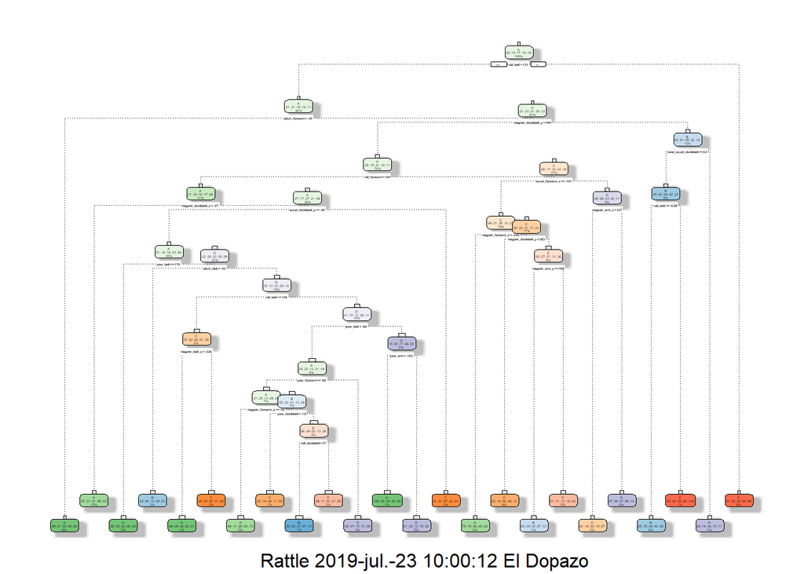

```r
#model
Treemodel <- rpart(classe ~ ., data=Train, method="class")
fancyRpartPlot(Treemodel)
```

```r
#predicting/cross-validation
predict_tree <- predict(Treemodel, Test, type = "class")
summarytree <- confusionMatrix(predict_tree, Test$classe)
summarytree
```

```
## Confusion Matrix and Statistics
##
##           Reference
## Prediction    A    B    C    D    E
##          A 1306  209   14   77   55
##          B   24  508   75   34   67
##          C   28  132  668   75   65
##          D   23   61   63  546   71
##          E   14   39   35   72  643
##
## Overall Statistics
##
##                Accuracy : 0.7486
##                  95% CI : (0.7362, 0.7607)
##     No Information Rate : 0.2845
##     P-Value [Acc > NIR] : < 2.2e-16
##
##                   Kappa : 0.68
##
##  Mcnemar's Test P-Value : < 2.2e-16
##
## Statistics by Class:
##
##                      Class: A Class: B Class: C Class: D Class: E
## Sensitivity            0.9362   0.5353   0.7813   0.6791   0.7137
## Specificity            0.8988   0.9494   0.9259   0.9468   0.9600
## Pos Pred Value         0.7863   0.7175   0.6901   0.7147   0.8007
## Neg Pred Value         0.9726   0.8949   0.9525   0.9377   0.9371
## Prevalence             0.2845   0.1935   0.1743   0.1639   0.1837
## Detection Rate         0.2663   0.1036   0.1362   0.1113   0.1311
## Detection Prevalence   0.3387   0.1444   0.1974   0.1558   0.1637
## Balanced Accuracy      0.9175   0.7424   0.8536   0.8130   0.8368
```

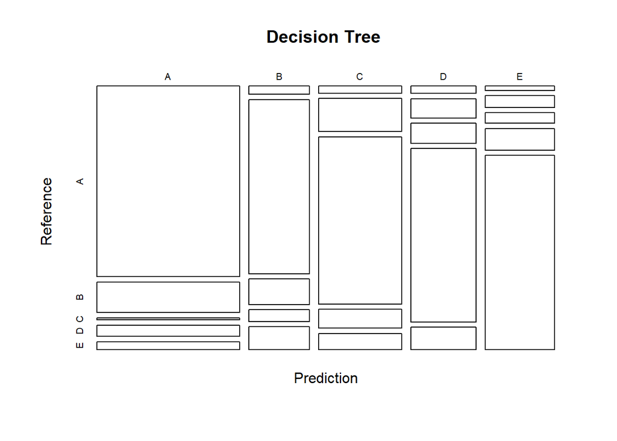

```r
#predictionplot
plot(summarytree$table, col = summarytree$byClass,
     main = "Decision Tree ")
```

####The accuracy for the Decision Tree model is 0.7486, its good but maybe we can find a model that fits better our data. We will try now the Random Forest model.

### Random Forest

```r
#model
controlForest <- trainControl(method="cv", number=3, verboseIter=FALSE)
Forestmodel <- train(classe ~ ., data=Train, method="rf", trControl=controlForest)
Forestmodel$finalModel
```

```
##
## Call:
##  randomForest(x = x, y = y, mtry = param$mtry)
##                Type of random forest: classification
##                      Number of trees: 500
## No. of variables tried at each split: 27
##
##         OOB estimate of  error rate: 0.63%
## Confusion matrix:
##      A    B    C    D    E  class.error
## A 4181    2    1    0    1 0.0009557945
## B   19 2822    6    1    0 0.0091292135
## C    0   10 2548    9    0 0.0074016362
## D    0    0   24 2382    6 0.0124378109
## E    0    2    3    8 2693 0.0048041390
```

```r
#predicting/cross-validation
predict_forest <- predict(Forestmodel, newdata=Test)
summaryforest <- confusionMatrix(predict_forest, Test$classe)
summaryforest
```

```
## Confusion Matrix and Statistics
##
##           Reference
## Prediction    A    B    C    D    E
##          A 1393    7    0    0    0
##          B    2  942    1    0    0
##          C    0    0  851    4    0
##          D    0    0    3  799    3
##          E    0    0    0    1  898
##
## Overall Statistics
##
##                Accuracy : 0.9957
##                  95% CI : (0.9935, 0.9973)
##     No Information Rate : 0.2845
##     P-Value [Acc > NIR] : < 2.2e-16
##
##                   Kappa : 0.9946
##
##  Mcnemar's Test P-Value : NA
##
## Statistics by Class:
##
##                      Class: A Class: B Class: C Class: D Class: E
## Sensitivity            0.9986   0.9926   0.9953   0.9938   0.9967
## Specificity            0.9980   0.9992   0.9990   0.9985   0.9998
## Pos Pred Value         0.9950   0.9968   0.9953   0.9925   0.9989
## Neg Pred Value         0.9994   0.9982   0.9990   0.9988   0.9993
## Prevalence             0.2845   0.1935   0.1743   0.1639   0.1837
## Detection Rate         0.2841   0.1921   0.1735   0.1629   0.1831
## Detection Prevalence   0.2855   0.1927   0.1743   0.1642   0.1833
## Balanced Accuracy      0.9983   0.9959   0.9972   0.9962   0.9982
```

#### The accuracy for the Random Forest model is 0.9957 almost 100% of right guessing,less than 0.43% out of sample error, we dont need to look for any other model, this one seems to be perfect.

### Conclusion

#### Now in this last section we will use the best model we got (Random Forest model) and try to predict the outcome for the 20 observations in the TestData set (this will answer the final course quiz).

```r
TestData_Quiz <- predict(Forestmodel, newdata=TestDClear)
TestData_Quiz
```

```
##  [1] B A B A A E D B A A B C B A E E A B B B
## Levels: A B C D E
```